# Detecting Species Redundancy in Pokemon GO - Gotta Catch (Most of) ’Em All

William Au

October 11, 2018

## Introduction

Pokemon GO is a mobile, location-based game where players can catch Pokemon for purposes of battling gyms, raiding gyms, defending gyms, trading or simply collecting. There are constraints such that a player cannot own all combinations of Pokemon in a play-able state (i.e., in their Pokemon box):

- The Pokemon box has finite limit.
- There are many species (currently, there are almost 400 species, but the game was launched with about 150).
- Many Pokemon have shiny variants within the same species.
- Many Pokemon have different or neutral gender within the same species.
- The game occasionally launches “event” Pokemon that spawn during certain events and will appear differently (e.g., wearing a hat or sunglasses).
- Pokemon of the same species usually have different “individual values”, which represent separate scores for attack, defense and stamina.

So the serious player must make choices with respect to which Pokemon to keep in a live Pokemon box, and which to discard. The purpose of my analysis was to use modeling and analytical techniques to see which Pokemon species most closely mimic others in terms of non-esthetic functionality; that is, if redundancy could be modeled between species, then players could effectively make keep/discard decisions according to their strategic objective.

## Methodology

Because I had no labeled data, my methodology consisted of using unsupervised machine learning. The modeling algorithm selected was density-based spatial clustering of applications with noise (DBSCAN) because of its known high-performance in results even when clusters are highly non-spherical (which was the case as depicted in the final model’s cluster plot).

## Data Acquisition

My analysis was based on the initial launch of the game with about 150 species because data was not available for a larger set of more recent species. I acquired two data sets:

- From Kaggle, a data set with each Pokemon’s first type, second type, combat points (CP) and hit points (HP) (https://www.kaggle.com/abcsds/pokemongo)
- From the game’s GamePress site, a spreadsheet with each Pokemon’s damage per second (DPS), total damage output (TDO), TDO per CP ratio and survival time against a Tier 5 raid boss (https://pokemongo.gamepress.gg/tdo-how-calculate-pokemons-ability)

## Admin

Here I did a few steps to prepare my R environment for the analysis.

```r
# ----- admin -----
rm(list = ls())  # clear environment
library(rmarkdown)  # markdown
library(knitr)  # knitr
library(tidyverse)  # for tidy data import and wrangling
library(factoextra)  # for cluster visualization
library(fpc)  # for dbscan clustering
library(caret)  # for dummy variables
library(cluster)  # for clustering
library(GGally)  # for matrix plotting
library(RColorBrewer)  # for color palettes
gc()  # garbage collection
set.seed(888)  # set seed for random number generation reproducibility
```

## Data Import, Transforming and Wrangling

To get the data set into a tidy data frame for modeling, I had to import, explore to get an understanding, transform and wrangle the data. Specific to transformation, I leveraged the dummyVars() function in the caret package to quickly perform one-hot encoding of all dummy variables.

Note that 6 species did not appear in the GamePress data, and these were suppressed from analysis. They were Caterpie, Metapod, Weedle, Kakuna, Magikarp and Ditto. Note that this suppression was minimal in impact as these species were considered very insignificant in terms of playing capabilities.

```r
# ----- import base data - kaggle's PG data set -----
pg01 <- as_tibble(read_csv("pokemonGO.csv",
        col_names = TRUE)) %>%
    dplyr::select(-`Image URL`) %>%
    rename(pm_nbr = `Pokemon No.`, typ1 = `Type 1`, typ2 = `Type 2`,
        max_cp = `Max CP`, max_hp = `Max HP`, name = Name) %>%
    arrange(pm_nbr)
glimpse(pg01)  # not all pokemon have secondary type
summary(pg01)  # no missing values except for secondary type

# ----- import base data - Game Press' IV spreadsheet -----
pg02 <- as_tibble(read_csv(
        "TDO SHEET BY DPS - Sheet1.csv",
        col_names = TRUE)) %>%
    mutate(pm_nbr = ifelse(dex >= 100, as.character(dex),
        ifelse(dex >= 10, str_c("0", as.character(dex)),
            str_c("00", as.character(dex))))) %>%
    select(pm_nbr, pokemon, WeaveDPS, TDO, `~TDO per CP`, `~SurvivalTime`) %>%
    rename(weave_dps = WeaveDPS, tdo = TDO, tdo_cp = `~TDO per CP`,
        surv_time = `~SurvivalTime`) %>%
    arrange(pm_nbr, desc(tdo)) %>%
    group_by(pm_nbr) %>%
    filter(tdo == max(tdo)) %>%
    filter(weave_dps == max(weave_dps)) %>%
    ungroup() %>%
    distinct(pm_nbr, pokemon, weave_dps, tdo, tdo_cp, surv_time)
glimpse(pg02)
summary(pg02)

# ----- transform by encoding dummy variables -----
dmy <- dummyVars("~ typ1 + typ2", data = pg01)
pg03 <- as_tibble(predict(dmy, newdata = pg01)) %>%
    replace(., is.na(.), 0) %>%
    mutate(
        typ_bug = as.factor(typ1Bug),
        typ_dragon = as.factor(typ1Dragon),
        typ_electric = as.factor(typ1Electric),
        typ_fairy = as.factor(pmax(typ1Fairy, typ2Fairy)),
        typ_fighting = as.factor(pmax(typ1Fighting, typ2Fighting)),
        typ_fire = as.factor(typ1Fire),
        typ_ghost = as.factor(typ1Ghost),
        typ_grass = as.factor(pmax(typ1Grass, typ2Grass)),
        typ_ground = as.factor(pmax(typ1Ground, typ2Ground)),
        typ_ice = as.factor(pmax(typ1Ice, typ2Ice)),
        typ_normal = as.factor(typ1Normal),
        typ_poison = as.factor(pmax(typ1Poison, typ2Poison)),
        typ_psychic = as.factor(pmax(typ1Psychic, typ2Psychic)),
        typ_rock = as.factor(pmax(typ1Rock, typ2Rock)),
        typ_water = as.factor(pmax(typ1Water, typ2Water)),
        typ_flying = as.factor(typ2Flying),
        typ_steel = as.factor(typ2Steel)) %>%
    bind_cols(pg01) %>%
    select(max_cp, max_hp, starts_with("typ_"))
summary(pg03)
glimpse(pg03)

# ----- wrangle to combine data sets -----
pg04 <- pg01 %>%
    left_join(pg02, by = "pm_nbr") %>%
    select(pm_nbr, name, typ1, typ2, weave_dps, tdo, tdo_cp, surv_time) %>%
    bind_cols(pg03) %>%
    filter(weave_dps >= 0)  # few small species missing
```

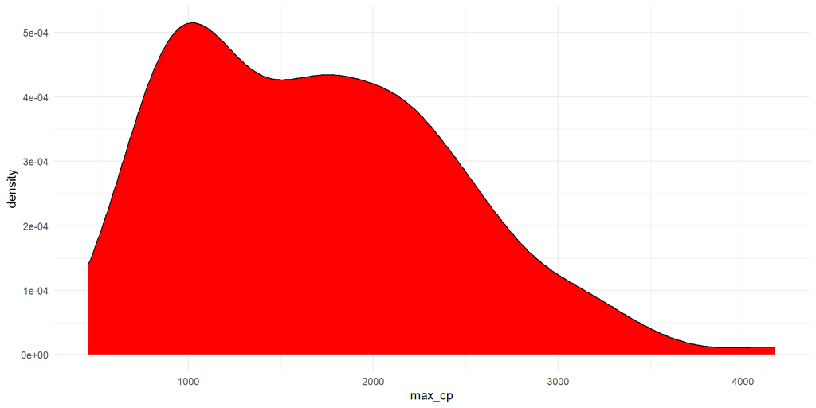

```r
# ----- explore KPI distributions -----
ggplot(data = pg04, aes(max_cp)) + geom_density(kernel = "gaussian",
    fill = "red") + theme_minimal()
```

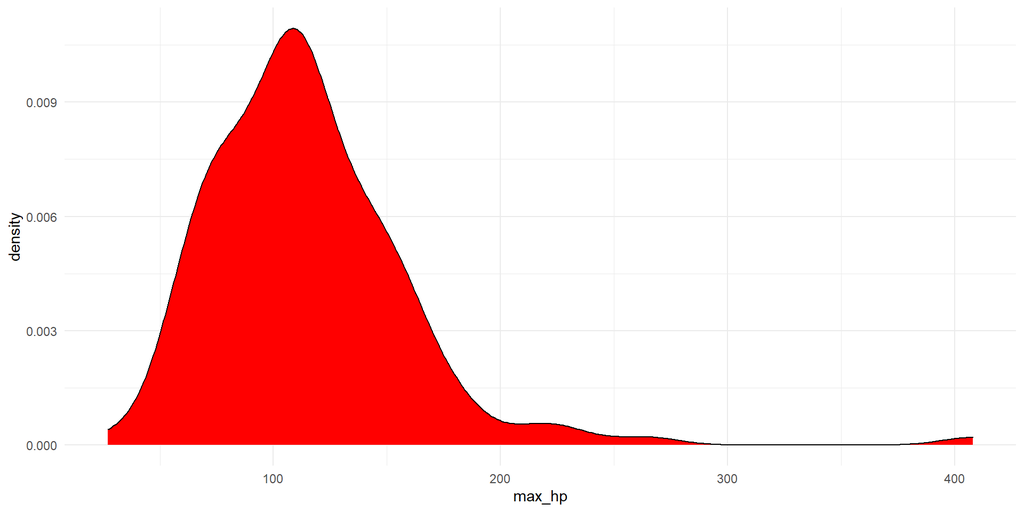

```r
ggplot(data = pg04, aes(max_hp)) + geom_density(kernel = "gaussian",
    fill = "red") + theme_minimal()
```

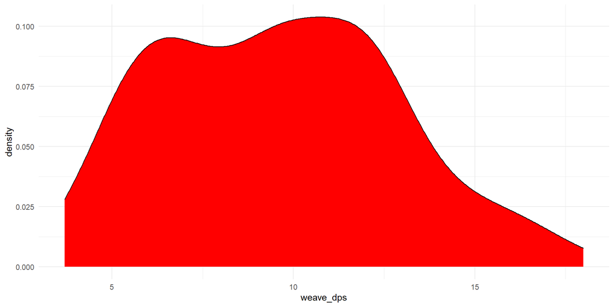

```r
ggplot(data = pg04, aes(weave_dps)) + geom_density(kernel = "gaussian",
    fill = "red") + theme_minimal()
```

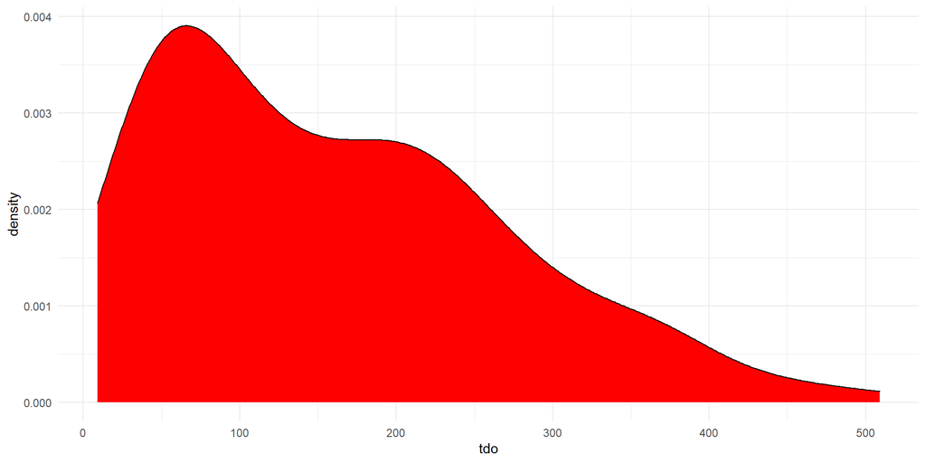

```r
ggplot(data = pg04, aes(tdo)) + geom_density(kernel = "gaussian",
    fill = "red") + theme_minimal()
```

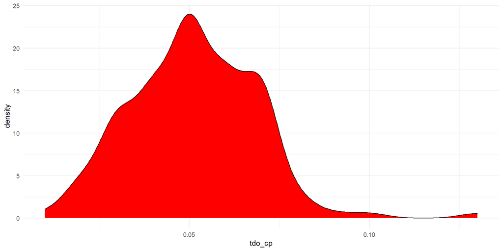

```r
ggplot(data = pg04, aes(tdo_cp)) + geom_density(kernel = "gaussian",
    fill = "red") + theme_minimal()
```

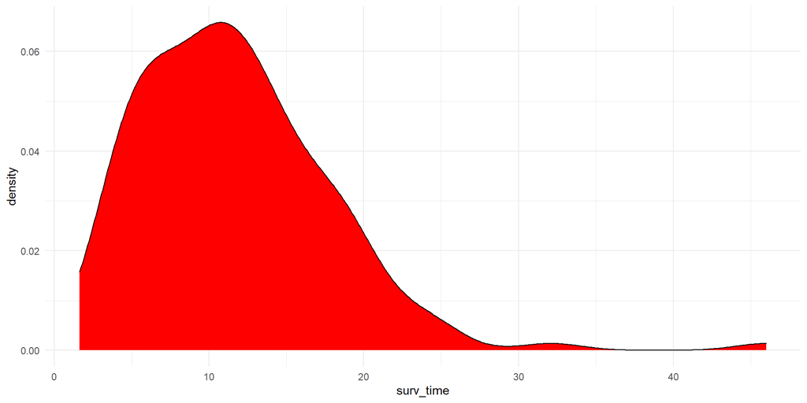

```r
ggplot(data = pg04, aes(surv_time)) + geom_density(kernel = "gaussian",
    fill = "red") + theme_minimal()
```

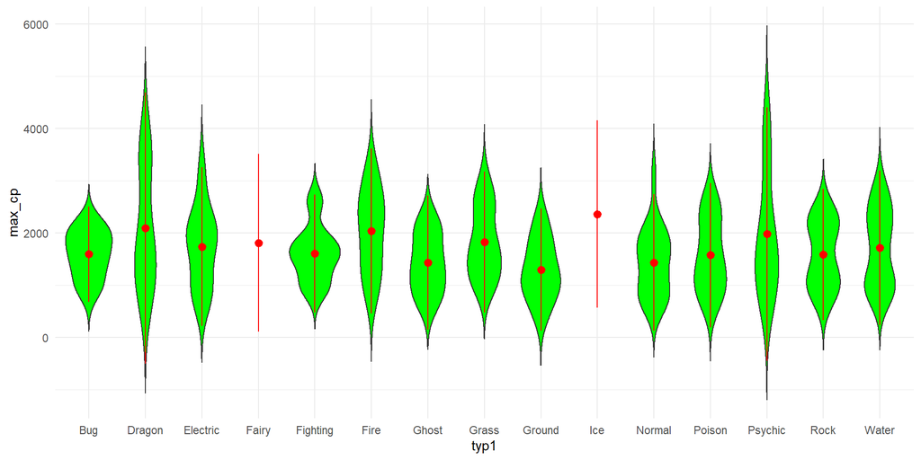

```r
# ----- explore KPI distributions by first type -----
ggplot(data = pg04, aes(x = typ1, y = max_cp)) +
    geom_violin(trim = FALSE, fill = "green") +
    stat_summary(fun.data = mean_sdl, geom = "pointrange", color = "red") +
    theme_minimal()
```

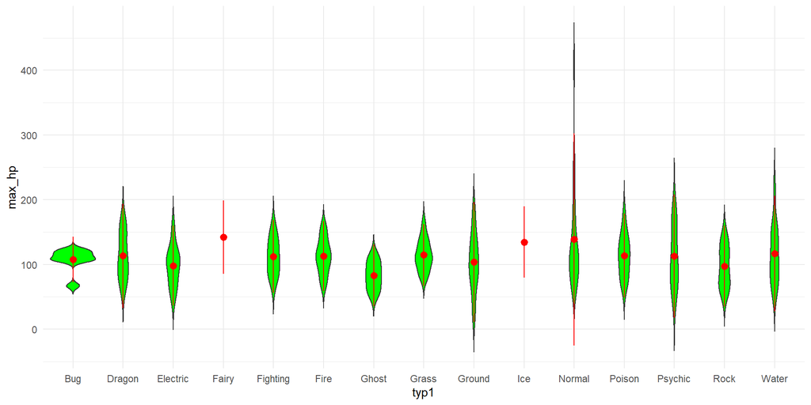

```r
ggplot(data = pg04, aes(x = typ1, y = max_hp)) +
    geom_violin(trim = FALSE, fill = "green") +
    stat_summary(fun.data = mean_sdl, geom = "pointrange", color = "red") +
    theme_minimal()
```

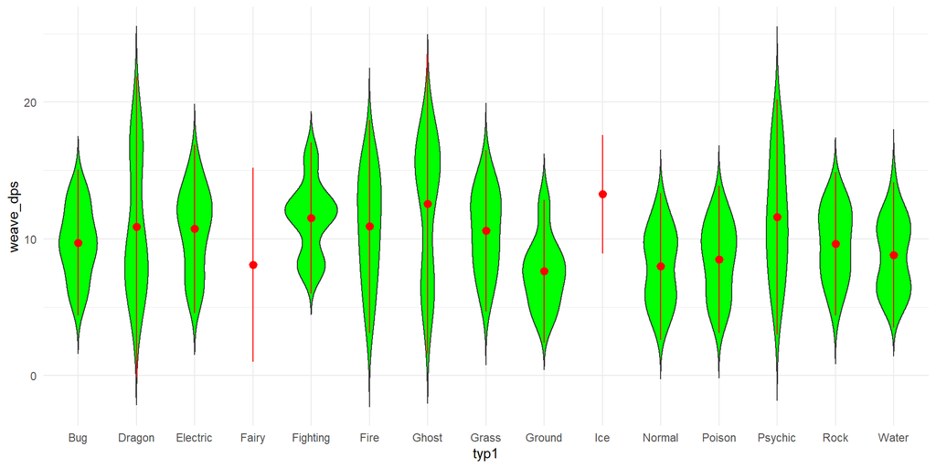

```r
ggplot(data = pg04, aes(x = typ1, y = weave_dps)) +
    geom_violin(trim = FALSE, fill = "green") +
    stat_summary(fun.data = mean_sdl, geom = "pointrange", color = "red") +
    theme_minimal()
```

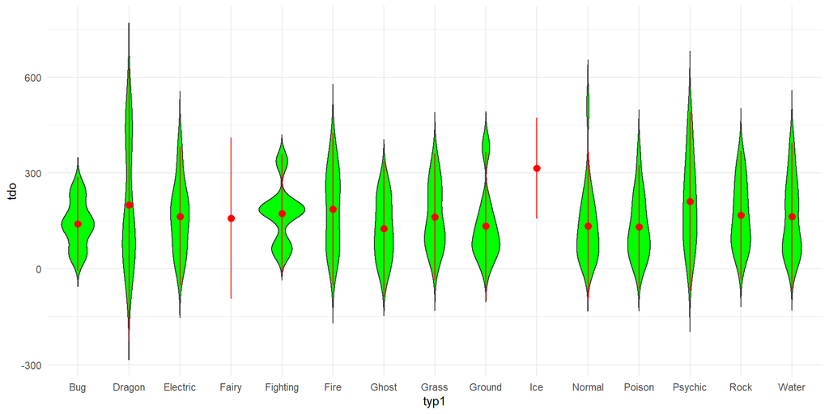

```r
ggplot(data = pg04, aes(x = typ1, y = tdo)) +
    geom_violin(trim = FALSE, fill = "green") +
    stat_summary(fun.data = mean_sdl, geom = "pointrange", color = "red") +
    theme_minimal()
```

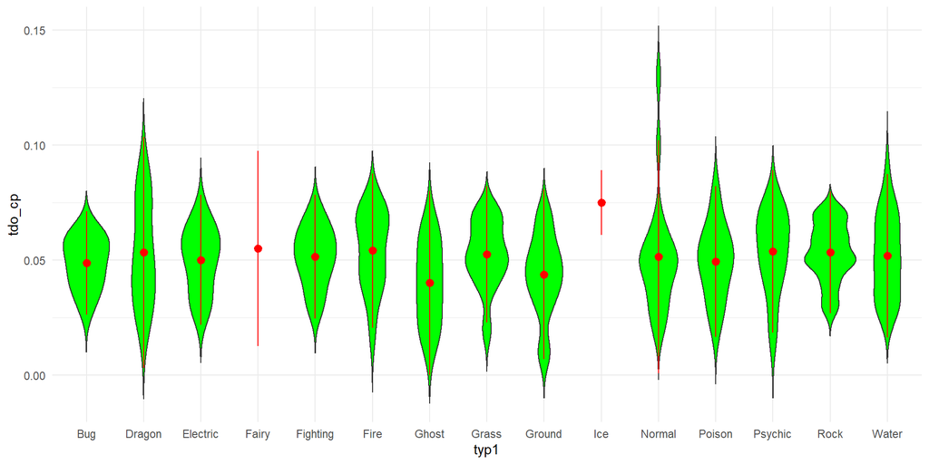

```r
ggplot(data = pg04, aes(x = typ1, y = tdo_cp)) +
    geom_violin(trim = FALSE, fill = "green") +
    stat_summary(fun.data = mean_sdl, geom = "pointrange", color = "red") +
    theme_minimal()
```

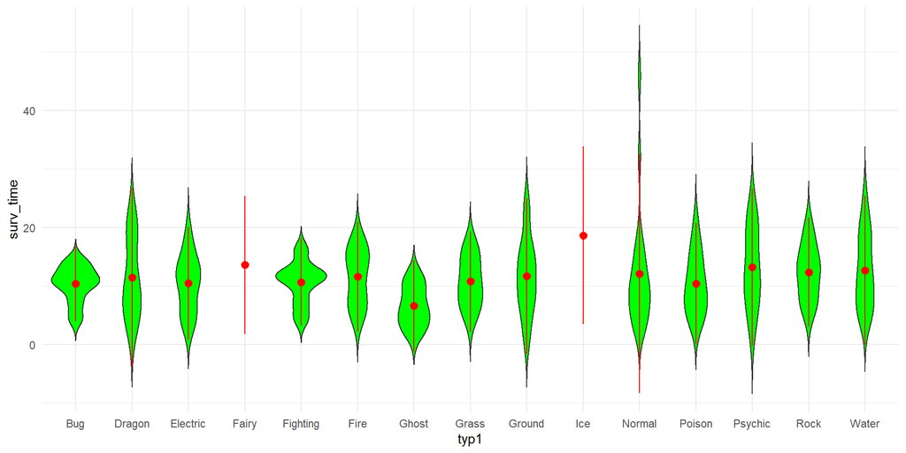

```r
ggplot(data = pg04, aes(x = typ1, y = surv_time)) +
    geom_violin(trim = FALSE, fill = "green") +
    stat_summary(fun.data = mean_sdl, geom = "pointrange", color = "red") +
    theme_minimal()
```

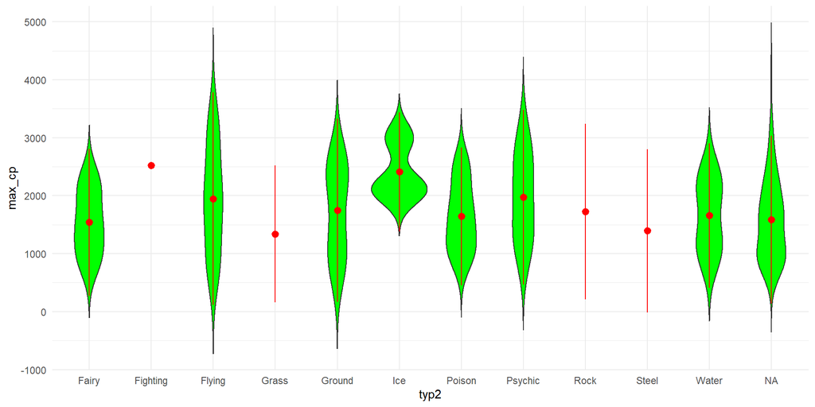

```r
# ----- explore KPI distributions by second type (if available) -----
ggplot(data = pg04, aes(x = typ2, y = max_cp)) +
    geom_violin(trim = FALSE, fill = "green") +
    stat_summary(fun.data = mean_sdl, geom = "pointrange", color = "red") +
    theme_minimal()
```

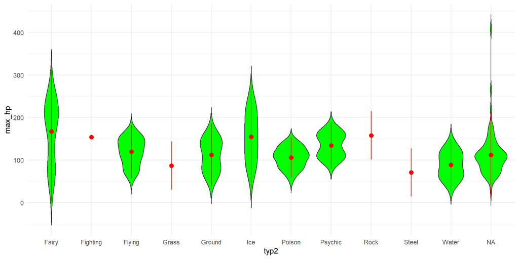

```r
ggplot(data = pg04, aes(x = typ2, y = max_hp)) +
    geom_violin(trim = FALSE, fill = "green") +
    stat_summary(fun.data = mean_sdl, geom = "pointrange", color = "red") +
    theme_minimal()
```

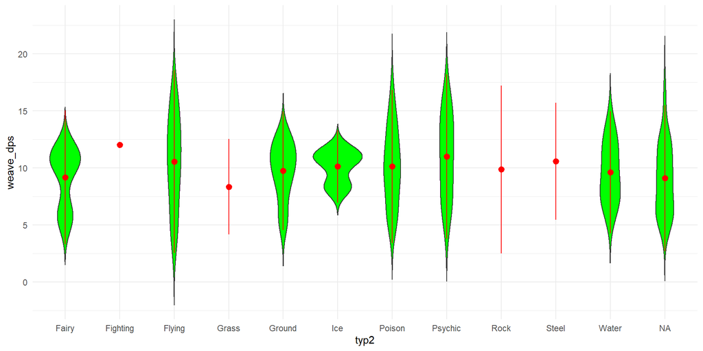

```r
ggplot(data = pg04, aes(x = typ2, y = weave_dps)) +
    geom_violin(trim = FALSE, fill = "green") +
    stat_summary(fun.data = mean_sdl, geom = "pointrange", color = "red") +
    theme_minimal()
```

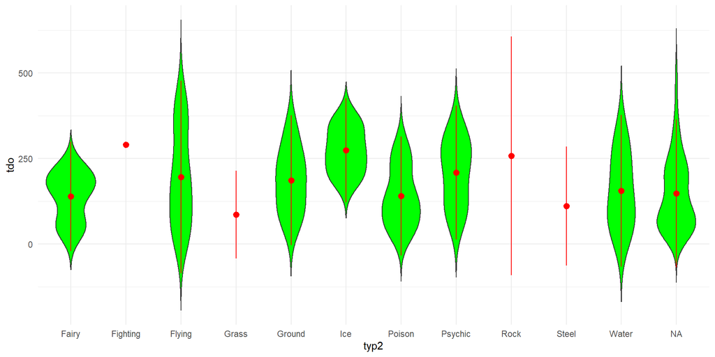

```r
ggplot(data = pg04, aes(x = typ2, y = tdo)) +
    geom_violin(trim = FALSE, fill = "green") +
    stat_summary(fun.data = mean_sdl, geom = "pointrange", color = "red") +
    theme_minimal()
```

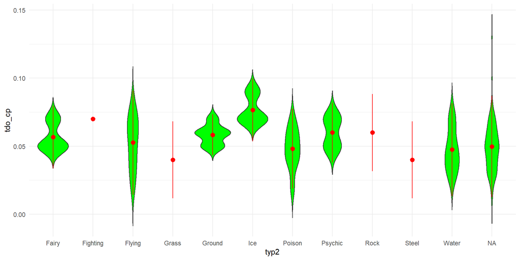

```r
ggplot(data = pg04, aes(x = typ2, y = tdo_cp)) +
    geom_violin(trim = FALSE, fill = "green") +
    stat_summary(fun.data = mean_sdl, geom = "pointrange", color = "red") +
    theme_minimal()
```

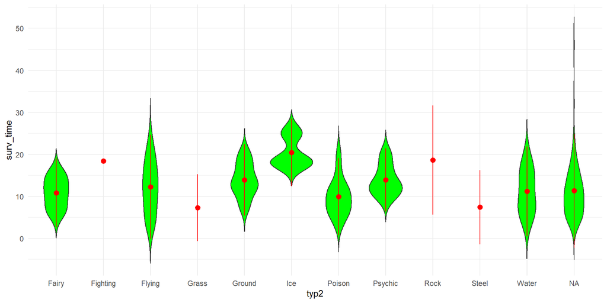

```r
ggplot(data = pg04, aes(x = typ2, y = surv_time)) +
    geom_violin(trim = FALSE, fill = "green") +
    stat_summary(fun.data = mean_sdl, geom = "pointrange", color = "red") +
    theme_minimal()
```

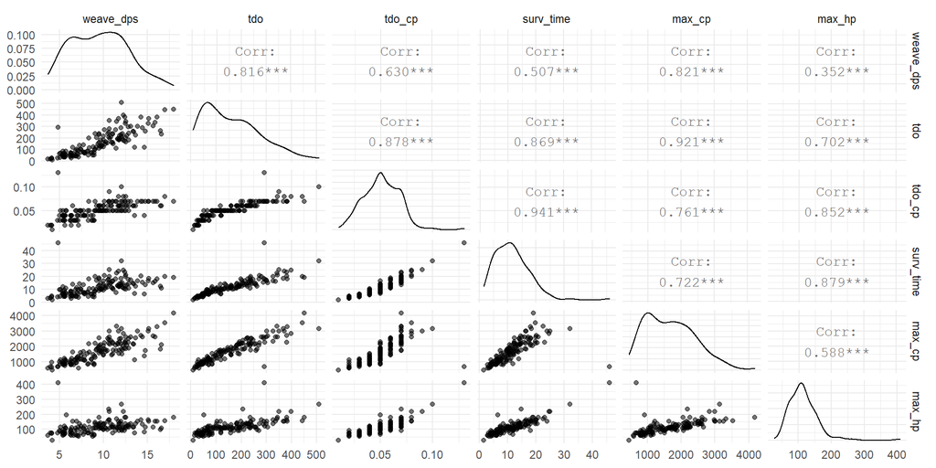

```r
# ----- explore two-way KPI distributions and correlations -----
ggpairs(pg04, columns = 5:10, aes(alpha = 0.1), upper = list("cor")) +
    theme_minimal()  # drop dps, tdo, tdo_cp b/c of high corr
```

From the exploratory data analysis, several insights were generated:

- All KPI’s were positively, right-skewed, signifying that there were a few prized species over the larger core group of species, at least univariately.
- Dragon and Psychic types had the most varied max CP.
- Max HP had less variance overall then max CP; however, Normal types had a significant max HP variance.
- Normal type had the largest variance, by far, in terms of survival time.
- As expected, all KPI’s had high positive correlation. In fact, some KPI’s were products of others (TDO = DPS * Survival time, TDO per CP = TDO / CP).

## Feature Selection

There was no “tried and true” feature selection algorithms for unsupervised machine learning, as opposed to supervised learning (e.g., elastic net, recursive feature elimation). I leveraged the correlation plot as well as subject-matter expertise as an avid player. Since DPS, TDO and TDO per CP had the highest correlations, I dropped these in favour of the more preferred KPI’s of max CP, max HP and survival time (preferred by a suspected majority of players).

As well, I kept all type 1 and type 2 classifications as dummy features.

```r
# ----- select variables for clustering -----
pg05 <- as.data.frame(pg04) %>%
    select(starts_with("typ_"), max_cp, max_hp, surv_time)
# as the correlation plot showed, dps, tdo, tdo_cp was dropped due to high corr
# daisy function doesn't like tibbles
```

## Data Preparation for Clustering

As data for clustering required distances or simmiliarities, I calculated the Gower distances between each Pokemon species (asymmetrically for the type dummy features and log-ratio for the max CP, max HP and survival time KPI’s).

```r
# ----- transform by calculating Gower distances with mixed data types -----
pg06_dist <- daisy(pg05, metric = "gower", type = list(
    asymm =
        c("typ_bug", "typ_dragon", "typ_electric", "typ_fairy", "typ_fighting",
            "typ_fire", "typ_ghost", "typ_grass", "typ_ground", "typ_ice",
            "typ_normal", "typ_poison", "typ_psychic", "typ_rock", "typ_water",
            "typ_flying", "typ_steel"),
    logratio = c("max_cp", "max_hp", "surv_time")))
summary(pg06_dist)
```

```
## 10440 dissimilarities, summarized :
##     Min.  1st Qu.   Median     Mean  3rd Qu.     Max.
## 0.002128 0.468950 0.554850 0.533150 0.620810 0.920690
## Metric :  mixed ;  Types = A, A, A, A, A, A, A, A, A, A, A, A, A, A, A, A, A, I, I, I
## Number of objects : 145
```

## Model Hyperparameter Tuning

A popular method for hyperparameter tuning for DBSCAN was using a k-nearest neighbour plot and varying k for the minimum number of members in a cluster and interpretting the plots for an elbow point for a hypothetical radius parameter. Using subject-matter expertise (e.g., high number of species, size of Pokemon box, relatively few species of legendary/mythical status), I only included 1-2 as the minimum number of species per cluster. I noted elbow points at radius parameters of 0.09 and 0.24 for k = 1, and 0.27 and 0.36 for k = 2, and these combinations formed my tuning grid.

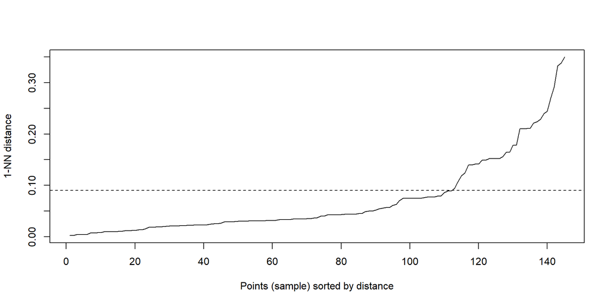

```r
# ----- tune hyperparameters for dbscan clustering -----
dbscan::kNNdistplot(pg06_dist, k = 1)
abline(h = 0.09, lty = 2)
```

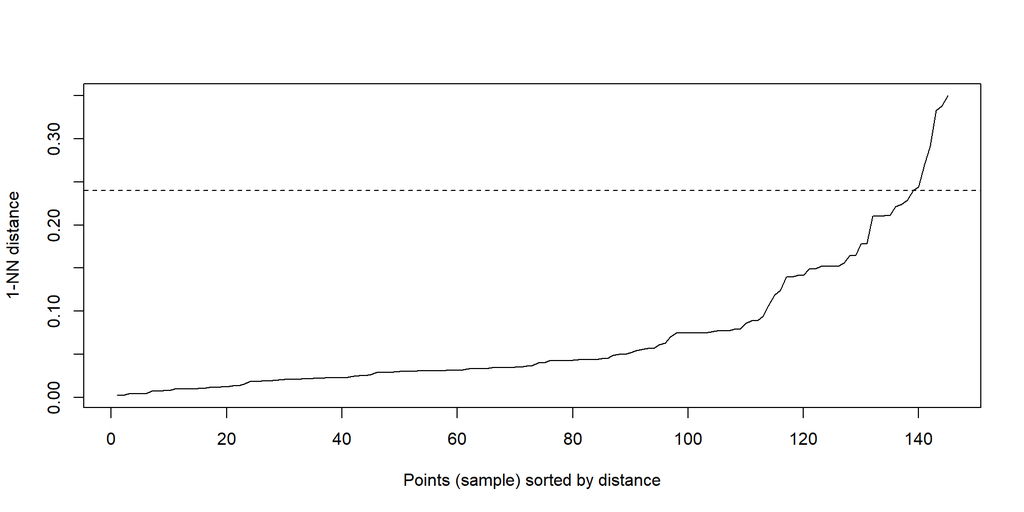

```r
dbscan::kNNdistplot(pg06_dist, k = 1)
abline(h = 0.24, lty = 2)
```

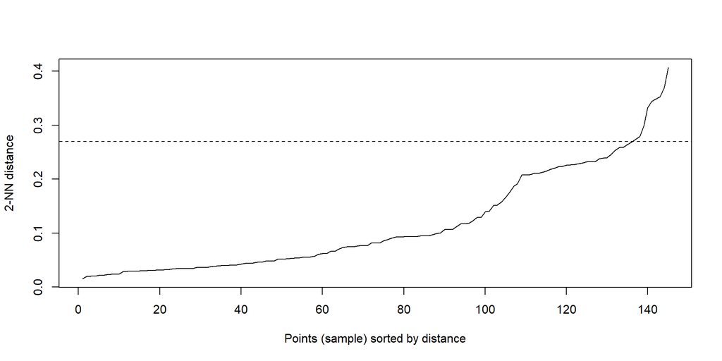

```r
dbscan::kNNdistplot(pg06_dist, k = 2)
abline(h = 0.27, lty = 2)
```

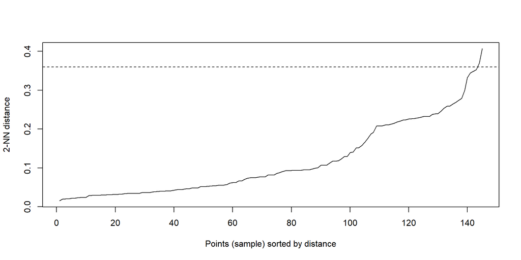

```r
dbscan::kNNdistplot(pg06_dist, k = 2)
abline(h = 0.36, lty = 2)
```

## Model Development Using DBSCAN for Clustering

I developed DBSCAN models across all 4 combinations in my tuning grid. To be concise, I only included the code and results for the final model below (hyperparameters of radius and minimum number of members of 0.24 and 1, respectively).

As the results showed, the final created 98 clusters ranging from 1 through 5 species within each cluster. Interpretting the cluster plot, the centroids were not dispersed uniformly across the first 2 principal components. This suggested that the game developers were strategic in creating the species and their characteristics.

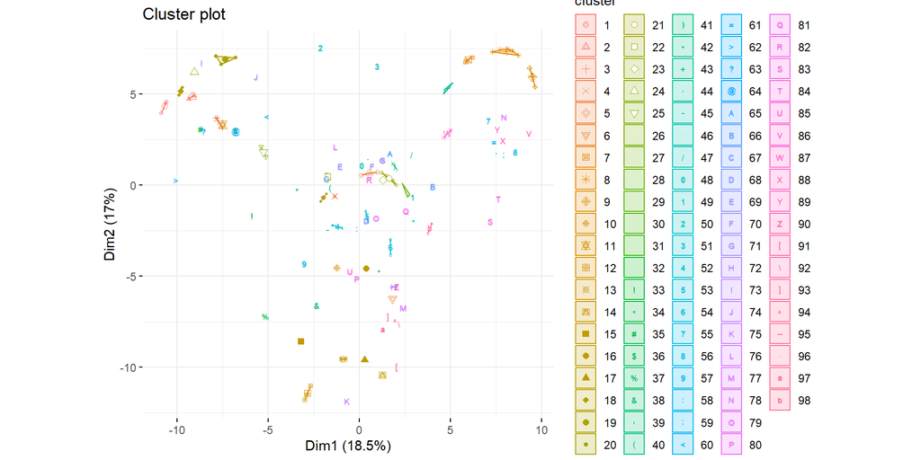

```r
# ----- conduct dbscan clustering -----
pg07_dbs <- fpc::dbscan(pg06_dist, eps = 0.24, MinPts = 1)
fviz_cluster(pg07_dbs, data = pg06_dist, stand = TRUE, ellipse = TRUE,
    show.clust.cent = TRUE, palette = "paired", geom = "point", pointsize = 1,
    repel = TRUE, ggtheme = theme_minimal()) + coord_fixed()
```

```r
# ----- tabulate member results -----
pg08_clus <- as_tibble(pg07_dbs$cluster) %>%
    bind_cols(pg04) %>%
    rename(cluster = value)
table(pg08_clus$cluster)
```

```
##
##  1  2  3  4  5  6  7  8  9 10 11 12 13 14 15 16 17 18 19 20 21 22 23 24 25 26
##  3  3  3  2  3  1  3  5  3  1  1  3  2  1  1  1  2  2  4  2  4  2  1  1  2  1
## 27 28 29 30 31 32 33 34 35 36 37 38 39 40 41 42 43 44 45 46 47 48 49 50 51 52
##  1  4  1  1  1  1  1  1  1  1  1  1  2  1  2  1  5  1  1  1  1  1  1  1  1  2
## 53 54 55 56 57 58 59 60 61 62 63 64 65 66 67 68 69 70 71 72 73 74 75 76 77 78
##  2  2  1  1  1  1  1  1  1  1  1  1  1  1  1  1  1  1  2  2  1  1  1  1  1  1
## 79 80 81 82 83 84 85 86 87 88 89 90 91 92 93 94 95 96 97 98
##  1  1  1  1  1  1  1  1  2  1  1  1  1  1  1  1  1  1  1  2
```

## Investigation of Model Results

As noted above, the cluster centroids did not appear to be randomly dispersed in the cluster plot. One particular pattern noticed was in the upper right of the plot, where clusters 43, 9, 8 and 7 seemed to form a parabolic shape. Wrangling the data uncovered the specific species (from lower left of parabola to upper right):

- Cluster #43: Horsea, Krabby, Poliwag, Shellder, Staryu
- Cluster #9: Blastoise, Golduck, Seaking
- Cluster #8: Kingler, Poliwhirl, Seadra, Seel, Wartortle
- Cluster #7: Goldeen, Psyduck, Squirtle

As an avid player, I could not mentally deduce the reasons or developer strategy (if any) for the parabolic shape.

```r
# ----- investigate parabolic cluster pattern in upper right of scatter -----
tmp <- pg08_clus %>%
    select(cluster, name) %>%
    filter(cluster %in% c(43, 9, 8, 7)) %>%
    mutate(order = ifelse(cluster == 43, 1,
        ifelse(cluster == 9, 2,
            ifelse(cluster == 8, 3, 4)))) %>%
    arrange(order, name)
```

## Summary of Results

As a player, many of the species were clustered in expected ways (e.g., Spearow and Pidgey being in the same cluster). However, some results were unexpected, such as Onix and Geodude being in the same cluster.

There was also a large number of clusters, and no 1-2 dominant clusters in terms of size. This was atypical of many clustering analyses, and suggested a large variance in Pokemon species and likely intentional game development strategies. In fact, the Pokemon catch phrase “Gotta Catch ’Em All” was quite appropriate, though the final model showed a more truthful phrase might be “Gotta Catch Most of ’Em All”.

In the absence of all other information, the model suggested that the full set of Pokemon species could be reduced through redundancy by 32% (i.e., (145 species - 98 clusters) / 145 species). For example, a player could develop a playing strategy where he/she keeps a single species in a particular cluster, while discarding the other species in the same cluster.

A detailed model summary, showing all species analyed with their cluster membership, was provided at the end.

## Conclusion

This model should be used as a starting point to identify redundancy, combined with player expertise and possibly refined with more data in order to make optimal keep/discard decisions. Again in the absence of all other information, such as playing experience, avid player advice or online research, the model suggested that a player could be successful in discarding 32% of Pokemon species without a detrimental loss in Pokemon box capabilities.

## Detailed Summary of Results

Below was the detailed summary of results, outlining all species analyzed with their cluster membership.

```r
# ----- print final model results -----
tmp <- pg08_clus %>%
    select(cluster, pm_nbr, name) %>%
    arrange(cluster, pm_nbr, name)
print(as.data.frame(tmp))
```

```
##     cluster pm_nbr            name
## 1         1    001       Bulbasaur
## 2         1    043          Oddish
## 3         1    069      Bellsprout
## 4         2    002         Ivysaur
## 5         2    044           Gloom
## 6         2    070      Weepinbell
## 7         3    003        Venusaur
## 8         3    045       Vileplume
## 9         3    071      Victreebel
## 10        4    004      Charmander
## 11        4    037          Vulpix
## 12        5    005      Charmeleon
## 13        5    058       Growlithe
## 14        5    077          Ponyta
```

[output cut: 131 more lines]

## ===== END OF ANALYSIS =====